# CFS 2025 Initial Descriptives

## Overview

```
**Respondents:** 170
**Questions:** 15
```

Response rate by project

| Project Name | Responses | Active Clients | Response Rate |
| --- | --- | --- | --- |
| Caritas My Home | 53 | 106 | 50% |
| HATC Upward | 37 | 88 | 42% |
| HACA Onward | 1 | 54 | 2% |
| Integral Care Fresh Start | 27 | 31 | 87% |
| Lifeworks Turtle Island | 10 | 14 | 71% |
| Lifeworks (+ Caritas + SAFE) YHDP RRH | 20 | 57 | 35% |
| Lifeworks CoC RRH | 20 | 34 | 59% |
| The Salvation Army (+ SAFE) Passages II | 2 | 27 | 7% |

## Top responses by question

[output not shown]

## Tables

**Are the services you are receiving based on what youve told your case manager you need**

Denominator n = 170

| Response | Count | Percent |
| --- | --- | --- |
| I got to choose what went into my service plan | 144 | 84.7% |
| My plan was unique to me but I did not have a lot of choice in what went into it | 13 | 7.6% |
| To participate in services I wanted I had to participate in services I did not want | 5 | 2.9% |
| Everyone got the same services no matter what | 4 | 2.4% |
| I felt forced to participate in services I did not want | 4 | 2.4% |

**Do program staff communicate with you about important updates or delays**

Denominator n = 170

| Response | Count | Percent |
| --- | --- | --- |
| Yes, they always communicate with me about important updates and delays | 141 | 82.9% |
| Mostly, but sometimes I don’t get updates when I need them | 18 | 10.6% |
| No, they do not communicate with me consistently | 11 | 6.5% |

**Do program staff follow through on what they say they will do in a timely manner such as submitting paperwork for benefits or securing resources for you**

Denominator n = 170

| Response | Count | Percent |
| --- | --- | --- |
| Yes, they always do what they say they will and are never late | 139 | 81.8% |
| Mostly, but there are occasional delays | 21 | 12.4% |
| No, they are not reliable in doing what they say they will in a timely manner | 10 | 5.9% |

**Do you feel like your case manager respects your identity such as your race gender pronouns culture disability or other aspects of who you are**

Denominator n = 170

| Response | Count | Percent |
| --- | --- | --- |
| Yes, I always feel respected by my case manager | 160 | 94.1% |
| I feel respected by case manager sometimes but not all the time | 5 | 2.9% |
| I feel neutral about my case manager | 2 | 1.2% |
| No, my case manager disrespects me more than respects me | 2 | 1.2% |
| No, my case manager is not respectful toward me at all | 1 | 0.6% |

**Do you feel that you can ask for what you need from your case manager**

Denominator n = 170

| Response | Count | Percent |
| --- | --- | --- |
| Yes, and what I ask for is usually given to me | 147 | 86.5% |
| Yes, and I do not usually get what I want but I feel heard | 8 | 4.7% |
| I do not have anything to ask but would be comfortable asking | 6 | 3.5% |
| I would only be comfortable asking for some things | 5 | 2.9% |
| No, I would not feel comfortable at all | 4 | 2.4% |

**How available are healthcare medical services**

Denominator n = 170

| Response | Count | Percent |
| --- | --- | --- |
| Very available | 87 | 51.2% |
| Somewhat available | 52 | 30.6% |
| Not at all available | 16 | 9.4% |
| I don’t need healthcare/medical services | 15 | 8.8% |

**How available are housing and rent payments through your housing program**

Denominator n = 170

| Response | Count | Percent |
| --- | --- | --- |
| It has been offered to me and I have received services with no issues | 162 | 95.3% |
| It has been offered but I have experienced a long wait to receive services | 7 | 4.1% |
| It has been offered to me but I don’t always get help when I need it | 1 | 0.6% |

**How available are mental health psychiatric services**

Denominator n = 170

| Response | Count | Percent |
| --- | --- | --- |
| Very available | 101 | 59.4% |
| Somewhat available | 44 | 25.9% |
| I don’t need mental health services | 17 | 10% |
| Not at all available | 8 | 4.7% |

**How available are services to help connect you with employment opportunities**

Denominator n = 170

| Response | Count | Percent |
| --- | --- | --- |
| I don’t need help with employment | 64 | 37.6% |
| Very available | 61 | 35.9% |
| Somewhat available | 36 | 21.2% |
| Not at all available | 9 | 5.3% |

**How available are services to help connect you with income benefits**

Denominator n = 170

| Response | Count | Percent |
| --- | --- | --- |
| Very available | 76 | 44.7% |
| Somewhat available | 45 | 26.5% |
| I don’t need help with income/benefits | 42 | 24.7% |
| Not at all available | 7 | 4.1% |

**How available are substance use recovery services**

Denominator n = 170

| Response | Count | Percent |
| --- | --- | --- |
| I don’t need substance use/recovery services | 92 | 54.1% |
| Very available | 54 | 31.8% |
| Somewhat available | 20 | 11.8% |
| Not at all available | 4 | 2.4% |

**How available is case management through your housing program**

Denominator n = 170

| Response | Count | Percent |
| --- | --- | --- |
| Very available | 137 | 80.6% |
| Somewhat available | 18 | 10.6% |
| Not at all available | 13 | 7.6% |
| I don’t need case management or I don’t need these services | 2 | 1.2% |

**How confident do you feel about keeping your housing long term without support from your program**

Denominator n = 170

| Response | Count | Percent |
| --- | --- | --- |
| Not at all confident – I would need significant help to keep my housing | 64 | 37.6% |
| Very confident – I have a stable income, resources, and a plan to stay housed | 37 | 21.8% |
| Somewhat confident – I have a plan but may need some support or resources | 33 | 19.4% |
| Unsure – I’m not sure if I could keep my housing long-term | 24 | 14.1% |
| Mostly not confident – I would likely struggle to stay housed without support | 12 | 7.1% |

**Which of the following services or supports are you currently receiving**

Denominator n = 170

| Response | Count | Percent |
| --- | --- | --- |
| Case manager | 136 | 80% |
| Income support (benefits - TANF/SNAP/Disability) | 94 | 55.3% |
| Medical/healthcare | 84 | 49.4% |
| Mental healthcare | 76 | 44.7% |
| Employment support/Job help | 19 | 11.2% |
| Housing assistance | 9 | 5.3% |
| Substance use support | 8 | 4.7% |
| Food assistance | 1 | 0.6% |
| N/A | 1 | 0.6% |

**Which of the following services or supports do you need right now**

Denominator n = 170

| Response | Count | Percent |
| --- | --- | --- |
| Case manager | 58 | 34.1% |
| Income support (benefits - TANF/SNAP/Disability) | 54 | 31.8% |
| Medical/healthcare | 49 | 28.8% |
| Mental healthcare | 44 | 25.9% |
| Employment support/Job help | 36 | 21.2% |
| None | 18 | 10.6% |
| N/A | 11 | 6.5% |
| Substance use support | 11 | 6.5% |
| Higher education | 2 | 1.2% |
| Housing assistance | 2 | 1.2% |
| Dental assistance | 1 | 0.6% |
| Food assistance | 1 | 0.6% |
| Legal aid | 1 | 0.6% |
| Public transportation | 1 | 0.6% |

## Plots

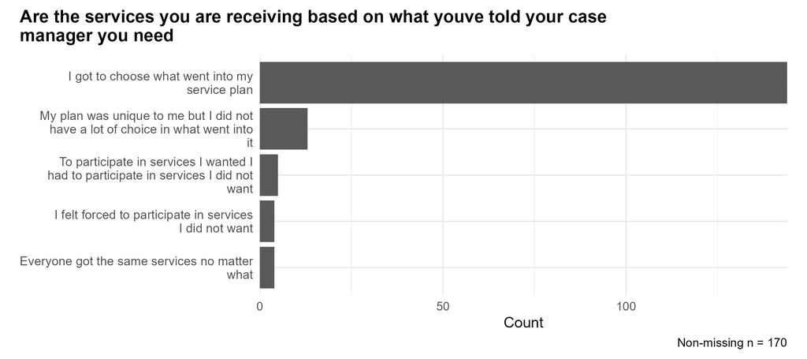

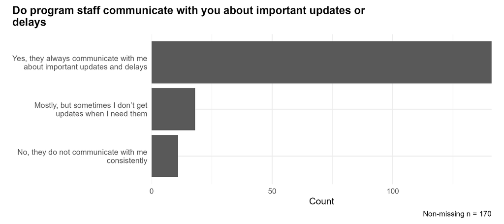

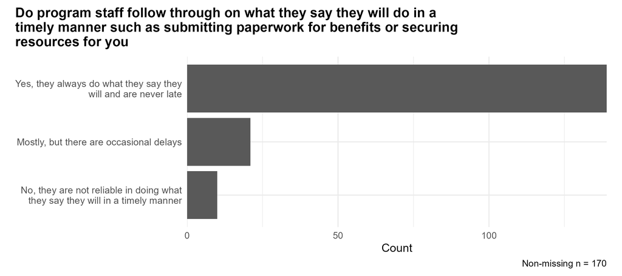

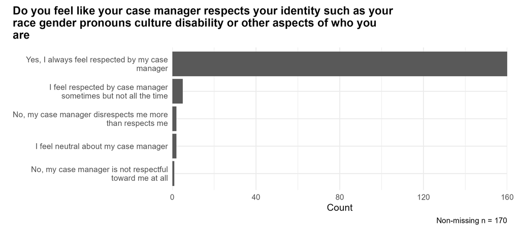

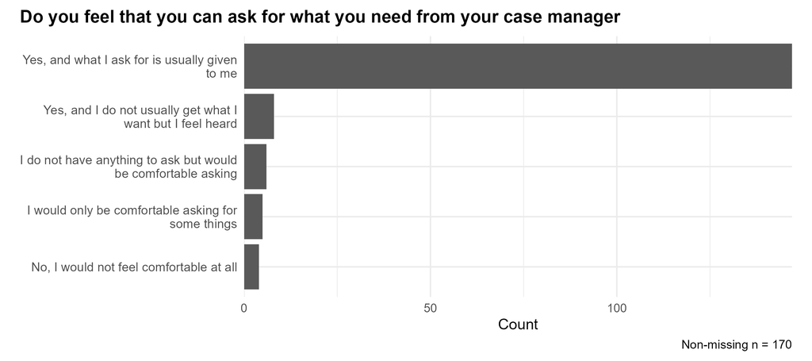

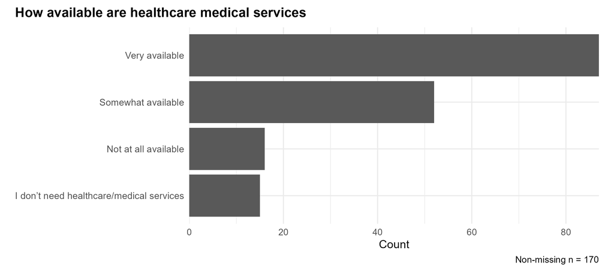

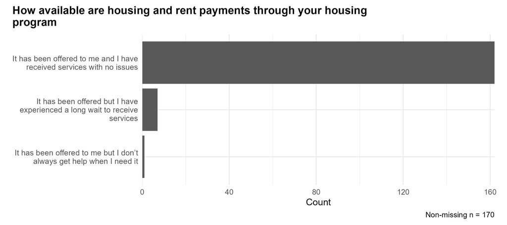

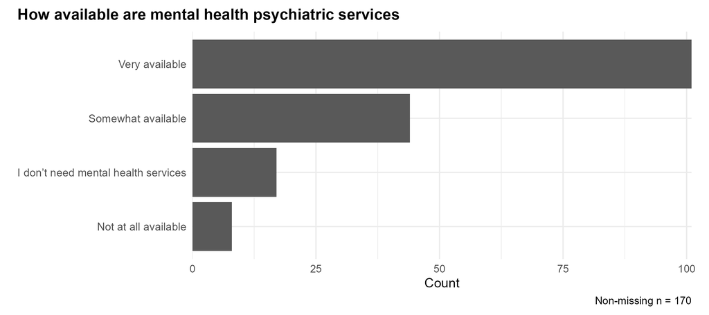

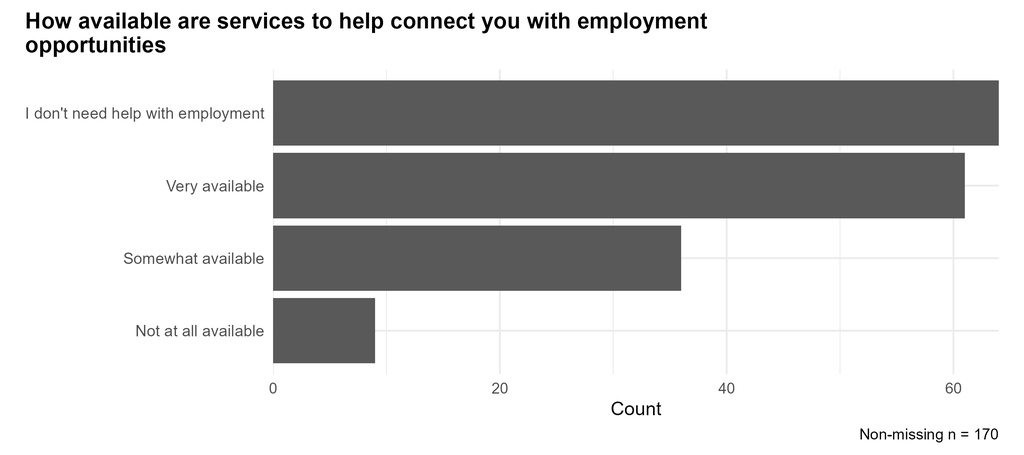

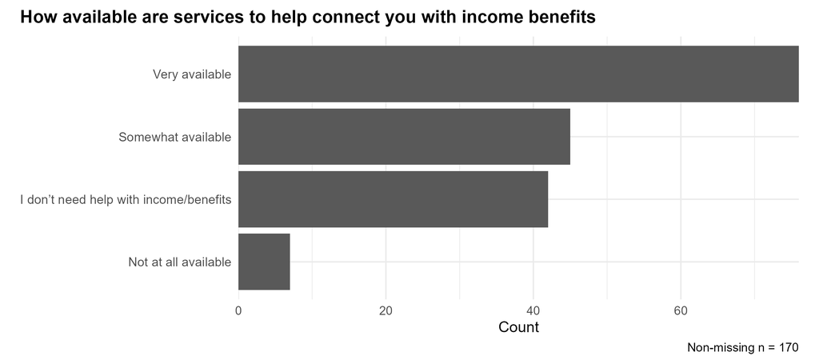

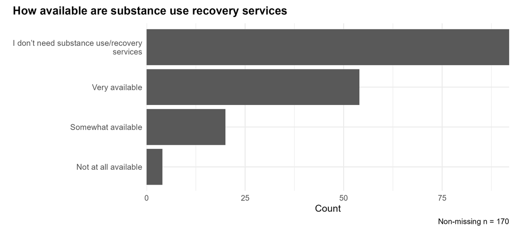

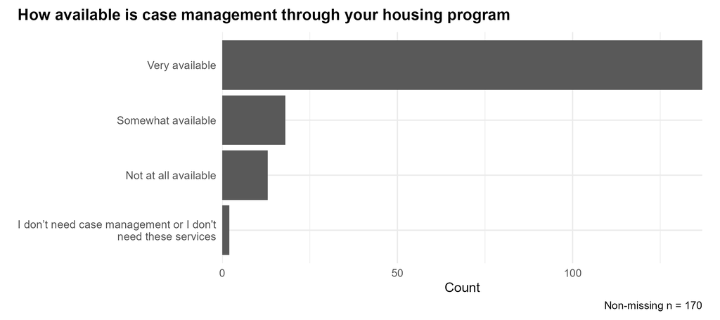

[3 more figures not shown]